# Spotify Extended Streaming Analysis: Tom

Produced by Tom Hook (GitHub: tomhook2)

11 May 2024

This document will provide stats and info on personal Spotify extended streaming data which can be downloaded from your [Spotify privacy settings](https://www.spotify.com/uk/account/privacy/) by selecting the “Extended streaming history” box and clicking “Request Data”.  
Data recorded includes offline data as data is stored in app and uploaded once the device is connected to the internet.

# Summary Stats

# Summary Stats by Year

## 2021

- In 2021 you listened to 26,260 minutes of music.
- You used Spotify on 351 days of the year.
- Your favourite song in 2021 was Fallowfield Hillbilly by Courteeners which you played 33 times.
- Your favourite artist of the year was Arctic Monkeys as you listened to 2,134 minutes of them, including 97 distinct songs.
- Your favourite podcast show of the year was JaackMaate’s Happy Hour which you spent 3,480 minutes listening to across 43 different episodes.

## 2022

- In 2022 you listened to 43,113 minutes of music.
- You used Spotify on 347 days of the year.
- Your favourite song in 2022 was Sabre Tooth by Jamie T which you played 38 times.
- Your favourite artist of the year was Kanye West as you listened to 5,151 minutes of them, including 115 distinct songs.
- Your favourite podcast show of the year was Fozcast - The Ben Foster Podcast which you spent 1,438 minutes listening to across 28 different episodes.

## 2023

- In 2023 you listened to 47,307 minutes of music.
- You used Spotify on 339 days of the year.
- Your favourite song in 2023 was Do You Love Me Yet? by Nothing But Thieves which you played 40 times.
- Your favourite artist of the year was Nothing But Thieves as you listened to 4,654 minutes of them, including 82 distinct songs.
- Your favourite podcast show of the year was The Rest Is Football which you spent 1,743 minutes listening to across 51 different episodes.

## 2024

- In 2024 you listened to 21,654 minutes of music.
- You used Spotify on 125 days of the year.
- Your favourite song in 2024 was BURN by ¥$ which you played 29 times.
- Your favourite artist of the year was Kanye West as you listened to 1,964 minutes of them, including 144 distinct songs.
- Your favourite podcast show of the year was The ArsenalVision Podcast - Arsenal FC which you spent 2,375 minutes listening to across 35 different episodes.

# Listening Time Over the Years

With a combined total of 8,933 minutes, April 2024 was the month in which you spent the most time listening to songs and podcasts combined on Spotify. Let’s see how this has changed over time.

## Music and Podcasts Combined

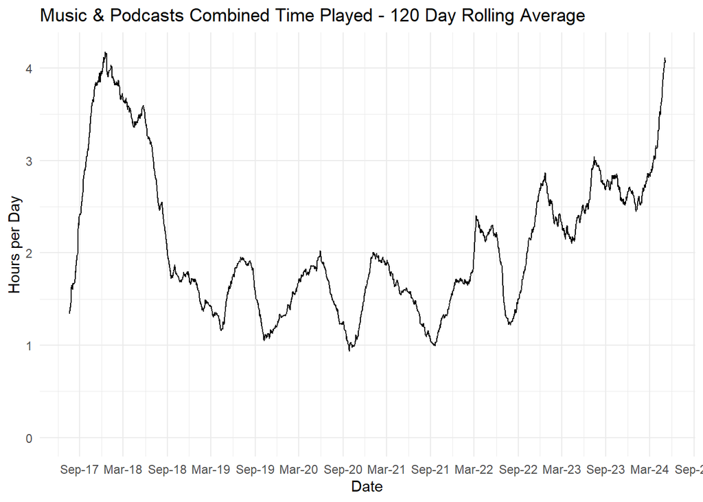

## Music Only

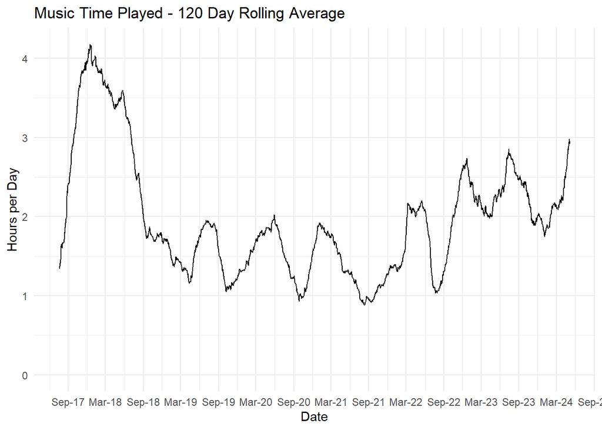

## Podcasts Only

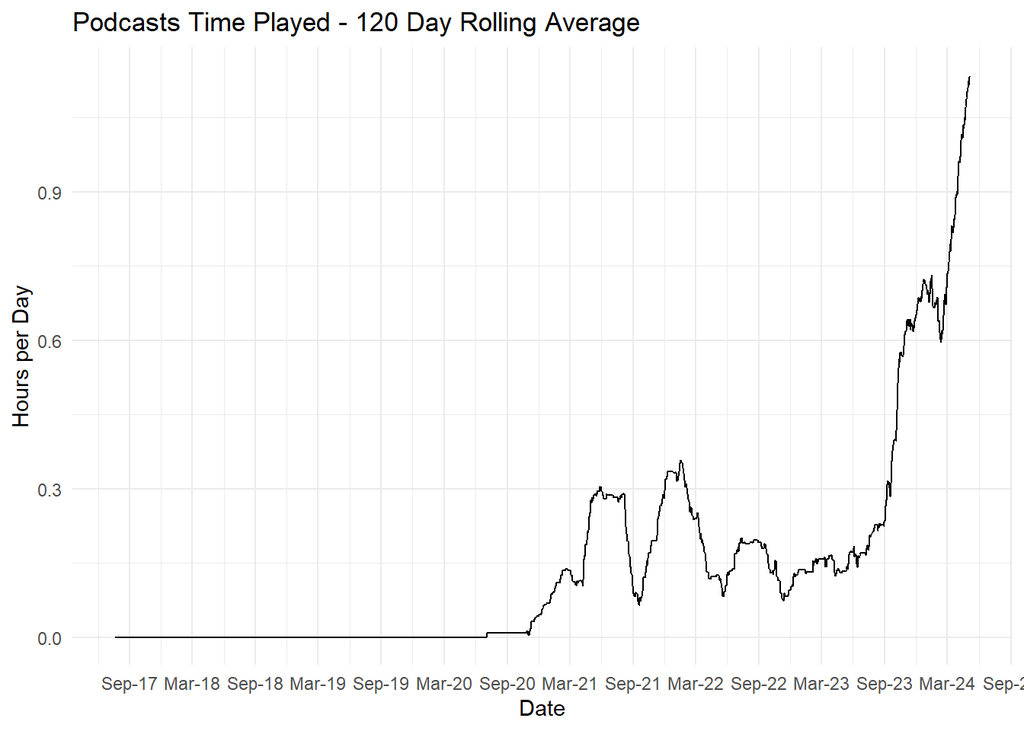

# Top 10 Artists, Albums, Songs, and Podcasts Each Year

We’ve seen some all time favourites, but what about some top 10s for artists, albums, songs, and podcasts for both all time and each year.

## Artists

### All Time

| Artist | Hours Played | Minutes Played | Distinct Songs |
| --- | --- | --- | --- |
| Arctic Monkeys | 430 | 25,787 | 135 |
| The Wombats | 326 | 19,562 | 156 |
| Jamie T | 288 | 17,269 | 138 |
| Fall Out Boy | 241 | 14,436 | 204 |
| Kanye West | 214 | 12,813 | 189 |
| Panic! At The Disco | 197 | 11,791 | 111 |
| Catfish and the Bottlemen | 169 | 10,163 | 67 |
| Nothing But Thieves | 161 | 9,672 | 100 |
| Circa Waves | 151 | 9,088 | 183 |
| Two Door Cinema Club | 146 | 8,776 | 112 |

### 2017

| Artist | Hours Played | Minutes Played | Distinct Songs |
| --- | --- | --- | --- |
| The Wombats | 94 | 5,662 | 59 |
| Fall Out Boy | 74 | 4,423 | 34 |
| Eminem | 66 | 3,989 | 72 |
| Panic! At The Disco | 59 | 3,537 | 38 |
| RAT BOY | 49 | 2,932 | 45 |
| Bastille | 36 | 2,133 | 27 |
| Arctic Monkeys | 26 | 1,543 | 27 |
| The Pigeon Detectives | 21 | 1,273 | 63 |
| The Killers | 21 | 1,255 | 33 |
| The Script | 17 | 1,024 | 23 |

### 2018

| Artist | Hours Played | Minutes Played | Distinct Songs |
| --- | --- | --- | --- |
| Arctic Monkeys | 107 | 6,415 | 114 |
| Fall Out Boy | 86 | 5,182 | 155 |
| The Wombats | 73 | 4,366 | 68 |
| Panic! At The Disco | 57 | 3,420 | 78 |
| High Tyde | 41 | 2,447 | 33 |
| Eminem | 37 | 2,230 | 55 |
| RAT BOY | 37 | 2,193 | 46 |
| Catfish and the Bottlemen | 32 | 1,911 | 46 |
| Bastille | 28 | 1,652 | 48 |
| The Vaccines | 22 | 1,314 | 39 |

### 2019

| Artist | Hours Played | Minutes Played | Distinct Songs |
| --- | --- | --- | --- |
| Arctic Monkeys | 66 | 3,949 | 97 |
| Catfish and the Bottlemen | 44 | 2,633 | 41 |
| Fall Out Boy | 37 | 2,244 | 76 |
| The Wombats | 34 | 2,036 | 71 |
| Jamie T | 27 | 1,608 | 63 |
| Panic! At The Disco | 27 | 1,604 | 58 |
| RAT BOY | 22 | 1,312 | 52 |
| Two Door Cinema Club | 22 | 1,296 | 45 |
| High Tyde | 19 | 1,133 | 30 |
| The Vaccines | 17 | 1,045 | 31 |

### 2020

| Artist | Hours Played | Minutes Played | Distinct Songs |
| --- | --- | --- | --- |
| Arctic Monkeys | 59 | 3,559 | 105 |
| Jamie T | 43 | 2,607 | 70 |
| The Wombats | 38 | 2,296 | 64 |
| DON BROCO | 27 | 1,628 | 56 |
| Two Door Cinema Club | 27 | 1,598 | 64 |
| Catfish and the Bottlemen | 26 | 1,577 | 38 |
| Fall Out Boy | 25 | 1,479 | 85 |
| Circa Waves | 24 | 1,431 | 66 |
| Bastille | 21 | 1,247 | 50 |
| Panic! At The Disco | 19 | 1,133 | 47 |

### 2021

| Artist | Hours Played | Minutes Played | Distinct Songs |
| --- | --- | --- | --- |
| Arctic Monkeys | 36 | 2,134 | 98 |
| Jamie T | 30 | 1,802 | 67 |
| Kanye West | 29 | 1,712 | 135 |
| DON BROCO | 24 | 1,458 | 60 |
| Courteeners | 19 | 1,114 | 70 |
| Two Door Cinema Club | 18 | 1,094 | 39 |
| The Wombats | 18 | 1,071 | 58 |
| Catfish and the Bottlemen | 15 | 921 | 35 |
| Circa Waves | 14 | 865 | 52 |
| Nothing But Thieves | 14 | 851 | 31 |

### 2022

| Artist | Hours Played | Minutes Played | Distinct Songs |
| --- | --- | --- | --- |
| Kanye West | 86 | 5,151 | 116 |
| Jamie T | 71 | 4,247 | 119 |
| Arctic Monkeys | 55 | 3,281 | 115 |
| Courteeners | 40 | 2,414 | 82 |
| The Wombats | 29 | 1,761 | 89 |
| Miles Kane | 25 | 1,505 | 54 |
| Circa Waves | 25 | 1,489 | 85 |
| DON BROCO | 22 | 1,325 | 54 |
| Nothing But Thieves | 20 | 1,215 | 51 |
| Catfish and the Bottlemen | 19 | 1,129 | 37 |

### 2023

| Artist | Hours Played | Minutes Played | Distinct Songs |
| --- | --- | --- | --- |
| Nothing But Thieves | 78 | 4,654 | 82 |
| Jamie T | 63 | 3,802 | 107 |
| Arctic Monkeys | 63 | 3,756 | 109 |
| Kanye West | 58 | 3,484 | 115 |
| Circa Waves | 38 | 2,268 | 98 |
| Courteeners | 34 | 2,057 | 86 |
| The Wombats | 30 | 1,773 | 61 |
| Miles Kane | 28 | 1,694 | 75 |
| DON BROCO | 28 | 1,651 | 54 |
| The Vaccines | 21 | 1,256 | 53 |

### 2024

| Artist | Hours Played | Minutes Played | Distinct Songs |
| --- | --- | --- | --- |
| Kanye West | 33 | 1,964 | 145 |
| Nothing But Thieves | 29 | 1,744 | 68 |
| Jamie T | 21 | 1,262 | 93 |
| Arctic Monkeys | 19 | 1,148 | 107 |
| Kendrick Lamar | 14 | 858 | 65 |
| Miles Kane | 14 | 828 | 65 |
| Courteeners | 13 | 781 | 68 |
| ¥$ | 13 | 752 | 19 |
| Circa Waves | 12 | 724 | 60 |
| The Wombats | 10 | 596 | 53 |

## Albums

### All Time

| Album | Artist | Hours Played | Minutes Played |
| --- | --- | --- | --- |
| Glitterbug | The Wombats | 104 | 6,233 |
| The Wombats Proudly Present... This Modern Glitch | The Wombats | 78 | 4,650 |
| Favourite Worst Nightmare | Arctic Monkeys | 74 | 4,424 |
| Whatever People Say I Am, That's What I'm Not | Arctic Monkeys | 72 | 4,293 |
| The Balcony | Catfish and the Bottlemen | 71 | 4,269 |
| Save Rock And Roll | Fall Out Boy | 71 | 4,242 |
| Death of a Bachelor | Panic! At The Disco | 65 | 3,885 |
| Panic Prevention | Jamie T | 60 | 3,595 |
| The Ride | Catfish and the Bottlemen | 58 | 3,469 |
| Beautiful People Will Ruin Your Life | The Wombats | 55 | 3,299 |

### 2017

| Album | Artist | Hours Played | Minutes Played |
| --- | --- | --- | --- |
| Glitterbug | The Wombats | 37 | 2,198 |
| Save Rock And Roll | Fall Out Boy | 36 | 2,173 |
| The Wombats Proudly Present… This Modern Glitch | The Wombats | 32 | 1,906 |
| Too Weird to Live, Too Rare to Die! | Panic! At The Disco | 25 | 1,492 |
| Proudly Present… A Guide to Love, Loss & Desperation | The Wombats | 22 | 1,333 |
| Death of a Bachelor | Panic! At The Disco | 21 | 1,272 |
| American Beauty/American Psycho | Fall Out Boy | 20 | 1,228 |
| Wild World | Bastille | 17 | 1,010 |
| SCUM | RAT BOY | 15 | 879 |
| 100 | The Hunna | 15 | 872 |

### 2018

| Album | Artist | Hours Played | Minutes Played |
| --- | --- | --- | --- |
| Favourite Worst Nightmare | Arctic Monkeys | 24 | 1,464 |
| Whatever People Say I Am, That’s What I’m Not | Arctic Monkeys | 23 | 1,402 |
| Glitterbug | The Wombats | 21 | 1,289 |
| Beautiful People Will Ruin Your Life | The Wombats | 18 | 1,088 |
| Folie à Deux | Fall Out Boy | 17 | 1,030 |
| The Wombats Proudly Present… This Modern Glitch | The Wombats | 17 | 1,011 |
| Save Rock And Roll | Fall Out Boy | 17 | 1,010 |
| The Balcony | Catfish and the Bottlemen | 16 | 968 |
| The Ride | Catfish and the Bottlemen | 16 | 942 |
| Death of a Bachelor | Panic! At The Disco | 15 | 876 |

### 2019

| Album | Artist | Hours Played | Minutes Played |
| --- | --- | --- | --- |
| The Balcony | Catfish and the Bottlemen | 17 | 1,032 |
| The Balance | Catfish and the Bottlemen | 12 | 712 |
| The Ride | Catfish and the Bottlemen | 12 | 705 |
| Glitterbug | The Wombats | 11 | 657 |
| Whatever People Say I Am, That’s What I’m Not | Arctic Monkeys | 10 | 620 |
| Favourite Worst Nightmare | Arctic Monkeys | 10 | 612 |
| Technology | DON BROCO | 10 | 601 |
| Tranquility Base Hotel & Casino | Arctic Monkeys | 10 | 588 |
| 8978-202545 | High Tyde | 9 | 510 |
| Beautiful People Will Ruin Your Life | The Wombats | 8 | 509 |

### 2020

| Album | Artist | Hours Played | Minutes Played |
| --- | --- | --- | --- |
| Carry On The Grudge | Jamie T | 12 | 733 |
| Glitterbug | The Wombats | 12 | 710 |
| Automatic | DON BROCO | 11 | 647 |
| Kings & Queens | Jamie T | 10 | 610 |
| The Balcony | Catfish and the Bottlemen | 10 | 576 |
| Technology | DON BROCO | 10 | 576 |
| AM | Arctic Monkeys | 9 | 549 |
| Humbug | Arctic Monkeys | 9 | 544 |
| The Wombats Proudly Present… This Modern Glitch | The Wombats | 9 | 531 |
| The Ride | Catfish and the Bottlemen | 9 | 518 |

### 2021

| Album | Artist | Hours Played | Minutes Played |
| --- | --- | --- | --- |
| My Beautiful Dark Twisted Fantasy | Kanye West | 11 | 659 |
| Everything You’ve Come To Expect | The Last Shadow Puppets | 9 | 533 |
| Moral Panic | Nothing But Thieves | 9 | 512 |
| Technology | DON BROCO | 7 | 413 |
| The Balcony | Catfish and the Bottlemen | 7 | 410 |
| Amazing Things | DON BROCO | 6 | 377 |
| St. Jude | Courteeners | 6 | 372 |
| Kings & Queens | Jamie T | 6 | 363 |
| Glitterbug | The Wombats | 6 | 345 |
| Carry On The Grudge | Jamie T | 6 | 344 |

### 2022

| Album | Artist | Hours Played | Minutes Played |
| --- | --- | --- | --- |
| My Beautiful Dark Twisted Fantasy | Kanye West | 23 | 1,403 |
| The Life Of Pablo | Kanye West | 19 | 1,162 |
| The Theory Of Whatever | Jamie T | 18 | 1,101 |
| Graduation | Kanye West | 15 | 884 |
| Panic Prevention | Jamie T | 15 | 879 |
| The College Dropout | Kanye West | 13 | 797 |
| Falcon | Courteeners | 11 | 673 |
| Everything You’ve Come To Expect | The Last Shadow Puppets | 10 | 600 |
| St. Jude | Courteeners | 9 | 568 |
| The Car | Arctic Monkeys | 9 | 559 |

### 2023

| Album | Artist | Hours Played | Minutes Played |
| --- | --- | --- | --- |
| Nothing But Thieves | Nothing But Thieves | 24 | 1,458 |
| Dead Club City | Nothing But Thieves | 19 | 1,113 |
| Broken Machine (Deluxe) | Nothing But Thieves | 14 | 866 |
| This Is Why | Paramore | 14 | 843 |
| To Pimp A Butterfly | Kendrick Lamar | 14 | 819 |
| The Theory Of Whatever | Jamie T | 13 | 752 |
| My Beautiful Dark Twisted Fantasy | Kanye West | 12 | 705 |
| Panic Prevention | Jamie T | 11 | 687 |
| Yeezus | Kanye West | 11 | 666 |
| Moral Panic | Nothing But Thieves | 11 | 642 |

### 2024

| Album | Artist | Hours Played | Minutes Played |
| --- | --- | --- | --- |
| VULTURES 1 | ¥$ | 12 | 737 |
| Nothing But Thieves | Nothing But Thieves | 9 | 524 |
| good kid, m.A.A.d city | Kendrick Lamar | 8 | 497 |
| Dead Club City | Nothing But Thieves | 7 | 397 |
| VULTURES 1 | Kanye West | 6 | 382 |
| Paramore | Paramore | 5 | 328 |
| Broken Machine (Deluxe) | Nothing But Thieves | 5 | 322 |
| Moral Panic | Nothing But Thieves | 5 | 314 |
| The College Dropout | Kanye West | 5 | 282 |
| Graduation | Kanye West | 5 | 272 |

## Songs

### All Time

| Song | Album | Artist | Times Played |
| --- | --- | --- | --- |
| Moving to New York | Proudly Present... A Guide to Love, Loss & Desperation | The Wombats | 234 |
| Tokyo (Vampires & Wolves) | The Wombats Proudly Present... This Modern Glitch | The Wombats | 210 |
| Teddy Picker | Favourite Worst Nightmare | Arctic Monkeys | 195 |
| Victorious | Death of a Bachelor | Panic! At The Disco | 194 |
| Give Me a Try | Glitterbug | The Wombats | 191 |
| Fluorescent Adolescent | Favourite Worst Nightmare | Arctic Monkeys | 189 |
| I Bet You Look Good On The Dancefloor | Whatever People Say I Am, That's What I'm Not | Arctic Monkeys | 189 |
| R U Mine? | AM | Arctic Monkeys | 184 |
| Brianstorm | Favourite Worst Nightmare | Arctic Monkeys | 180 |
| Lethargy | Wild World | Bastille | 174 |

### 2017

| Song | Album | Artist | Times Played |
| --- | --- | --- | --- |
| Tokyo (Vampires & Wolves) | The Wombats Proudly Present… This Modern Glitch | The Wombats | 90 |
| Moving to New York | Proudly Present… A Guide to Love, Loss & Desperation | The Wombats | 83 |
| Let’s Dance to Joy Division | Proudly Present… A Guide to Love, Loss & Desperation | The Wombats | 81 |
| I Bet You Look Good On The Dancefloor | Whatever People Say I Am, That’s What I’m Not | Arctic Monkeys | 76 |
| What You Know | Tourist History | Two Door Cinema Club | 76 |
| Lethargy | Wild World | Bastille | 73 |
| REVOLUTION | REVOLUTION | RAT BOY | 73 |
| GET OVER IT | GET OVER IT EP | RAT BOY | 71 |
| The Phoenix | Save Rock And Roll | Fall Out Boy | 71 |
| Vegas Lights | Too Weird to Live, Too Rare to Die! | Panic! At The Disco | 71 |

### 2018

| Song | Album | Artist | Times Played |
| --- | --- | --- | --- |
| Fluorescent Adolescent | Favourite Worst Nightmare | Arctic Monkeys | 66 |
| Moving to New York | Proudly Present… A Guide to Love, Loss & Desperation | The Wombats | 64 |
| Brianstorm | Favourite Worst Nightmare | Arctic Monkeys | 58 |
| Pretty Visitors | Humbug | Arctic Monkeys | 58 |
| Old Yellow Bricks | Favourite Worst Nightmare | Arctic Monkeys | 57 |
| Teddy Picker | Favourite Worst Nightmare | Arctic Monkeys | 56 |
| 505 | Favourite Worst Nightmare | Arctic Monkeys | 55 |
| When The Sun Goes Down | Whatever People Say I Am, That’s What I’m Not | Arctic Monkeys | 51 |
| D is for Dangerous | Favourite Worst Nightmare | Arctic Monkeys | 49 |
| Lucy | Lucy | Ten Tonnes | 49 |

### 2019

| Song | Album | Artist | Times Played |
| --- | --- | --- | --- |
| R U Mine? | AM | Arctic Monkeys | 40 |
| Cocoon | The Balcony | Catfish and the Bottlemen | 39 |
| Breezeblocks | An Awesome Wave | alt-J | 37 |
| Tyrants | The Balcony | Catfish and the Bottlemen | 36 |
| Fallout | The Balcony | Catfish and the Bottlemen | 33 |
| Overlap | The Balance | Catfish and the Bottlemen | 31 |
| Pacifier | The Balcony | Catfish and the Bottlemen | 31 |
| Sidewinder | The Balcony | Catfish and the Bottlemen | 31 |
| Mission | The Balance | Catfish and the Bottlemen | 30 |
| Undercover Martyn | Tourist History | Two Door Cinema Club | 30 |

### 2020

| Song | Album | Artist | Times Played |
| --- | --- | --- | --- |
| Not Nineteen Forever | St. Jude | Courteeners | 34 |
| Torn Apart (Bastille Vs. GRADES) | VS. (Other People’s Heartache, Pt. III) | Bastille | 29 |
| Moving to New York | Proudly Present… A Guide to Love, Loss & Desperation | The Wombats | 27 |
| R U Mine? | AM | Arctic Monkeys | 27 |
| Nerve | Automatic | DON BROCO | 26 |
| Our Perfect Disease | The Wombats Proudly Present… This Modern Glitch | The Wombats | 26 |
| Automatic | Automatic | DON BROCO | 25 |
| Emoticons | Glitterbug | The Wombats | 24 |
| Money Power Fame - Remastered | Automatic | DON BROCO | 24 |
| Snap Out Of It | AM | Arctic Monkeys | 24 |

### 2021

| Song | Album | Artist | Times Played |
| --- | --- | --- | --- |
| Fallowfield Hillbilly | St. Jude | Courteeners | 33 |
| Unperson | Moral Panic | Nothing But Thieves | 23 |
| Be Somebody Good | What’s It Like Over There? | Circa Waves | 20 |
| Castro Dies | Kings & Queens | Jamie T | 20 |
| Everything You’ve Come To Expect | Everything You’ve Come To Expect | The Last Shadow Puppets | 20 |
| Sticks ‘N’ Stones | Kings & Queens | Jamie T | 20 |
| All Of The Lights | My Beautiful Dark Twisted Fantasy | Kanye West | 19 |
| Aviation | Everything You’ve Come To Expect | The Last Shadow Puppets | 19 |
| Sometimes | Erratic Cinematic | Gerry Cinnamon | 19 |
| Acrylic | Acrylic | Courteeners | 18 |

### 2022

| Song | Album | Artist | Times Played |
| --- | --- | --- | --- |
| Sabre Tooth | The Theory Of Whatever | Jamie T | 38 |
| No More Parties In LA | The Life Of Pablo | Kanye West | 35 |
| Talk Is Cheap | The Theory Of Whatever | Jamie T | 35 |
| 90s Cars | The Theory Of Whatever | Jamie T | 34 |
| Real Friends | The Life Of Pablo | Kanye West | 34 |
| Old Republican | The Theory Of Whatever | Jamie T | 33 |
| Gorgeous | My Beautiful Dark Twisted Fantasy | Kanye West | 32 |
| Flashing Lights | Graduation | Kanye West | 31 |
| Dark Fantasy | My Beautiful Dark Twisted Fantasy | Kanye West | 30 |
| Fallowfield Hillbilly | St. Jude | Courteeners | 29 |

### 2023

| Song | Album | Artist | Times Played |
| --- | --- | --- | --- |
| Do You Love Me Yet? | Dead Club City | Nothing But Thieves | 40 |
| Graveyard Whistling | Nothing But Thieves | Nothing But Thieves | 39 |
| Hostage | Nothing But Thieves | Nothing But Thieves | 38 |
| You First | This Is Why | Paramore | 37 |
| Running Out Of Time | This Is Why | Paramore | 35 |
| City Haunts | Dead Club City | Nothing But Thieves | 34 |
| If I Get High | Nothing But Thieves | Nothing But Thieves | 33 |
| Never Going Under | Never Going Under | Circa Waves | 33 |
| Excuse Me | Nothing But Thieves | Nothing But Thieves | 32 |
| The News | This Is Why | Paramore | 31 |

### 2024

[output not shown]

## Podcasts

### All Time

| Show | Hours Played | Minutes Played | Shows Played |
| --- | --- | --- | --- |
| JaackMaate’s Happy Hour | 94 | 5,644 | 75 |
| The Rest Is Football | 57 | 3,445 | 107 |
| Fozcast - The Ben Foster Podcast | 43 | 2,560 | 45 |
| The AutoAlex Podcast | 42 | 2,528 | 32 |
| The ArsenalVision Podcast - Arsenal FC | 40 | 2,375 | 35 |
| Let's Talk FPL | 37 | 2,206 | 90 |
| NEW: That Peter Crouch Podcast | 34 | 2,034 | 52 |
| The Poker Coaching Podcast with Jonathan Little | 19 | 1,144 | 131 |
| The Running Channel Podcast | 16 | 979 | 32 |
| The Trial | 15 | 877 | 45 |

### 2017

| Show | Hours Played | Minutes Played | Shows Played |
| --- | --- | --- | --- |

### 2018

| Show | Hours Played | Minutes Played | Shows Played |
| --- | --- | --- | --- |

### 2019

| Show | Hours Played | Minutes Played | Shows Played |
| --- | --- | --- | --- |

### 2020

| Show | Hours Played | Minutes Played | Shows Played |
| --- | --- | --- | --- |
| The Poker Coaching Podcast with Jonathan Little | 8 | 472 | 56 |
| Wafflin’ | 1 | 57 | 1 |
| Smart Poker Study Podcast | 0 | 21 | 1 |

### 2021

| Show | Hours Played | Minutes Played | Shows Played |
| --- | --- | --- | --- |
| JaackMaate’s Happy Hour | 58 | 3,480 | 43 |
| Fozcast - The Ben Foster Podcast | 15 | 911 | 13 |
| The Poker Coaching Podcast with Jonathan Little | 10 | 622 | 74 |
| Off Menu with Ed Gamble and James Acaster | 1 | 65 | 1 |
| WHO THE F*** ARE ARCTIC MONKEYS? | 0 | 25 | 1 |
| What Did You Expect – Music & Talk – From The Vaccines? (Anniversary Edition) | 0 | 23 | 1 |
| Shaun Attwoods True Crime Podcast | 0 | 10 | 1 |

### 2022

| Show | Hours Played | Minutes Played | Shows Played |
| --- | --- | --- | --- |
| Fozcast - The Ben Foster Podcast | 24 | 1,438 | 28 |
| JaackMaate’s Happy Hour | 23 | 1,406 | 21 |
| NEW: That Peter Crouch Podcast | 7 | 424 | 11 |

### 2023

| Show | Hours Played | Minutes Played | Shows Played |
| --- | --- | --- | --- |
| The Rest Is Football | 29 | 1,743 | 51 |
| The AutoAlex Podcast | 22 | 1,296 | 15 |
| NEW: That Peter Crouch Podcast | 21 | 1,257 | 28 |
| The Trial | 15 | 877 | 45 |
| JaackMaate’s Happy Hour | 13 | 757 | 12 |
| The Ripple Effect with James Lawrence Allcott | 7 | 412 | 8 |
| The Running Channel Podcast | 6 | 383 | 14 |
| Racism at Work Podcast | 5 | 310 | 6 |
| Let’s Talk FPL | 4 | 252 | 11 |
| Fozcast - The Ben Foster Podcast | 4 | 211 | 4 |

### 2024

| Show | Hours Played | Minutes Played | Shows Played |
| --- | --- | --- | --- |
| The ArsenalVision Podcast - Arsenal FC | 40 | 2,375 | 35 |
| Let’s Talk FPL | 33 | 1,954 | 79 |
| The Rest Is Football | 28 | 1,702 | 56 |
| The AutoAlex Podcast | 21 | 1,232 | 17 |
| The Running Channel Podcast | 10 | 595 | 18 |
| NEW: That Peter Crouch Podcast | 6 | 353 | 13 |
| The Ripple Effect with James Lawrence Allcott | 2 | 115 | 3 |
| The Poker Coaching Podcast with Jonathan Little | 1 | 49 | 2 |
| The Gooner Talk | 0 | 21 | 3 |

# Favourite Artists over Time

Taking a look at your top artists of all time, let’s see when they may’ve come in and out of favour.

## Total

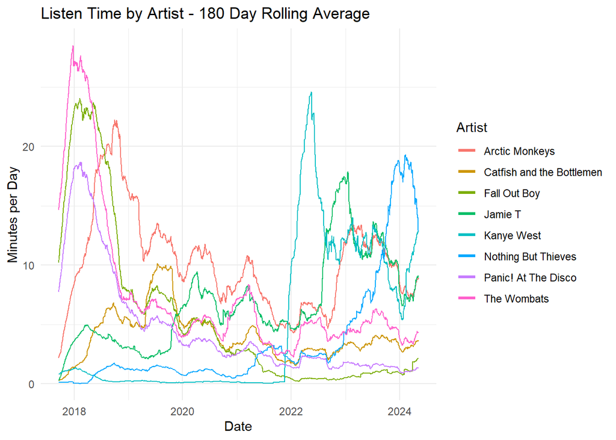

## Percent

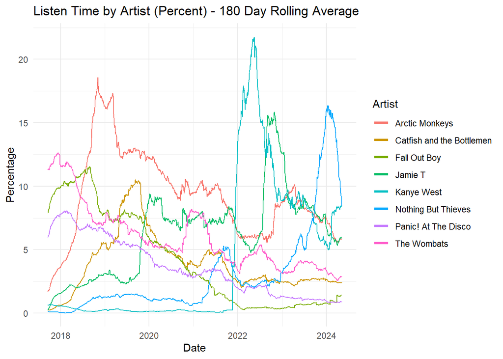

## Heatmap

There’s only so many artists you can fit on a chart… Here’s your top 25 artists, showing the percentage of playtime each artist took up for each year.

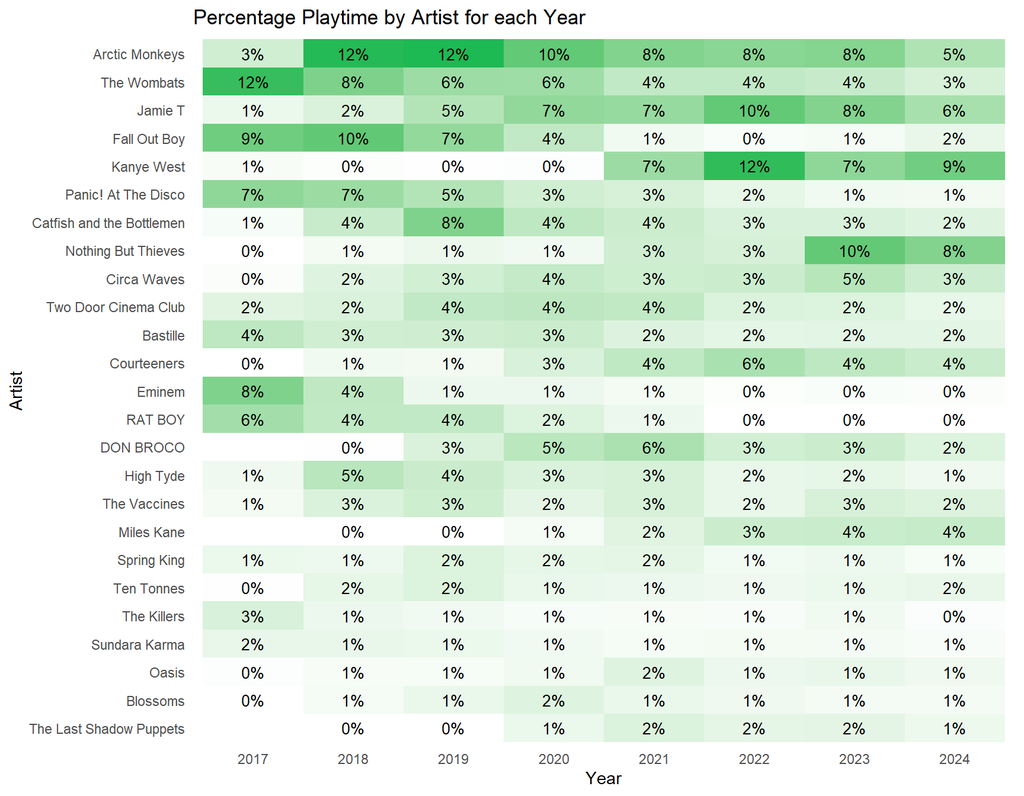

# Listening Time by Day of the Week

Have you ever wondered whether you tend to listen to more music or podcasts on weekends or weekdays? Perhaps you listen to more in your leisure time, or maybe you prefer to get grooving whilst working…

Here’s your listening time split by day of the week.

## Overall

Looking at the table, it looks like you enjoy listening mostly on weekdays!

| Day of Week | Percent | Hours Played |
| --- | --- | --- |
| Friday | 16.8% | 930 |
| Wednesday | 16.3% | 900 |
| Thursday | 15.6% | 863 |
| Tuesday | 14.9% | 825 |
| Monday | 14.6% | 810 |
| Saturday | 11.1% | 613 |
| Sunday | 10.6% | 589 |

## Heatmap

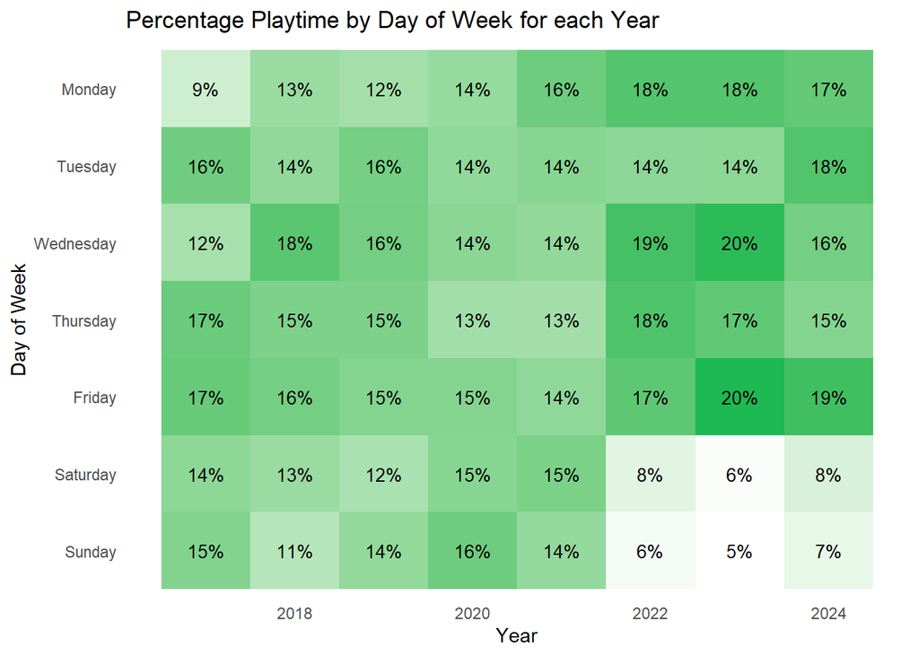

# Listening Time vs Distinct Song Count

We know you’ve spent the most amount of time listening to Arctic Monkeys over the history of the account, but it’s actually Fall Out Boy that have the most distinct songs you’ve listened to.

Use the tabs to see where your favourite artists are placed in terms of distinct songs played, and time spent listening in each year.

## All Time

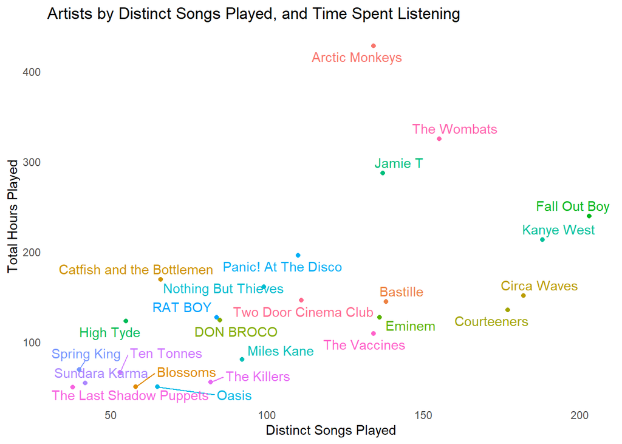

## 2017

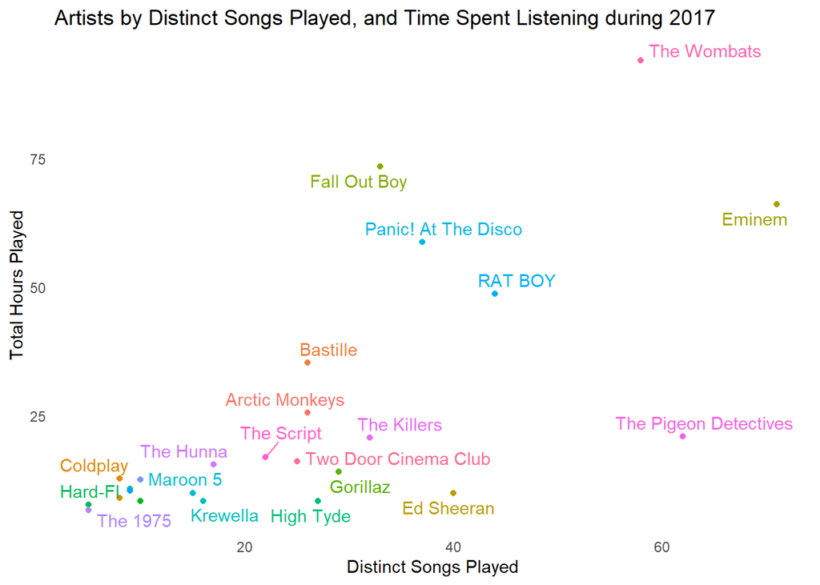

## 2018

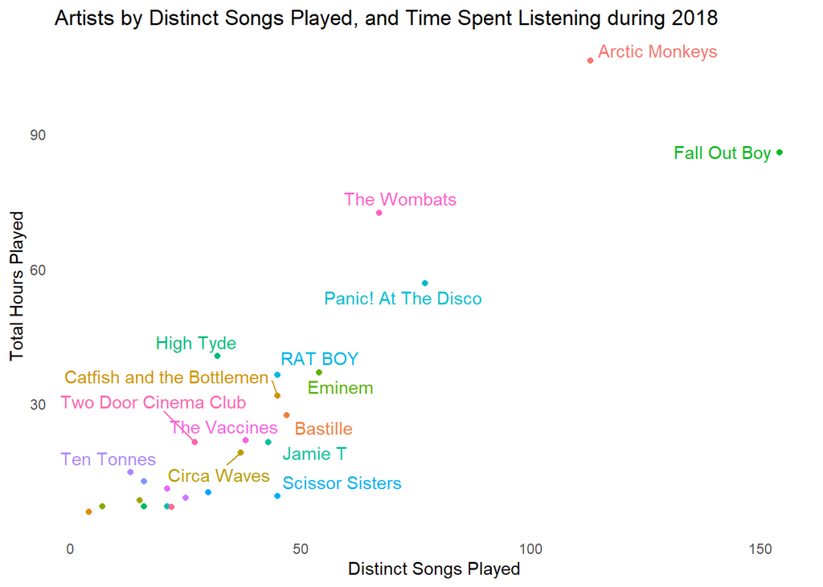

## 2019

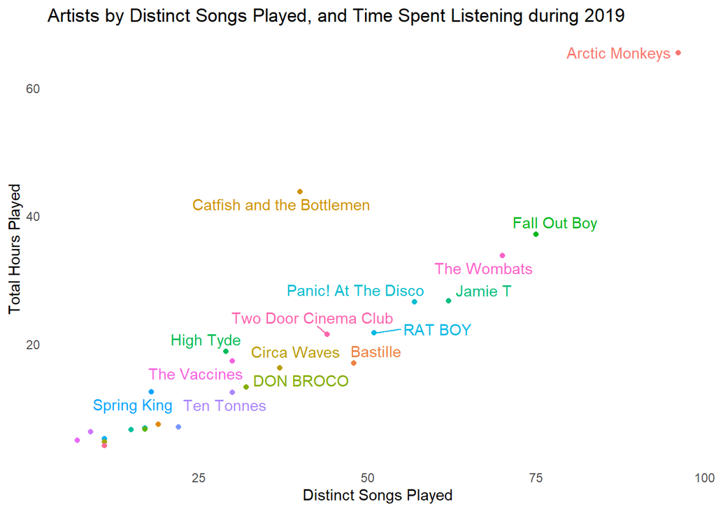

## 2020

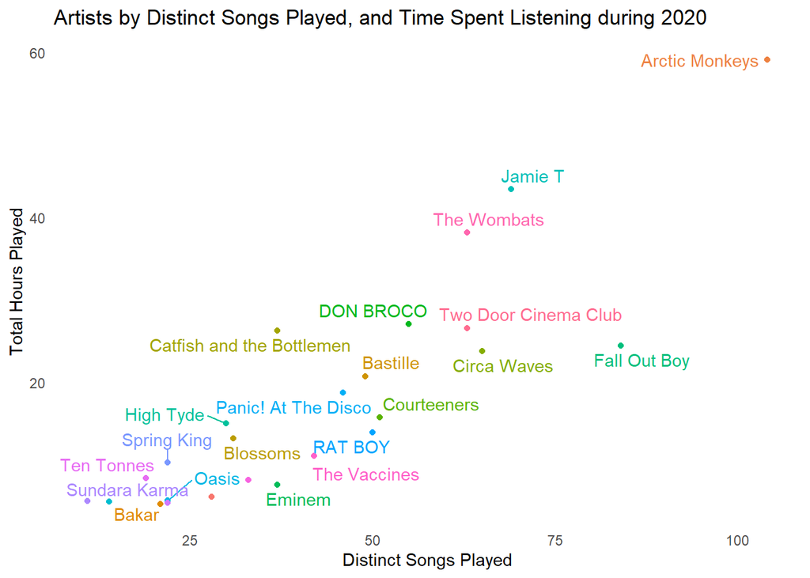

## 2021

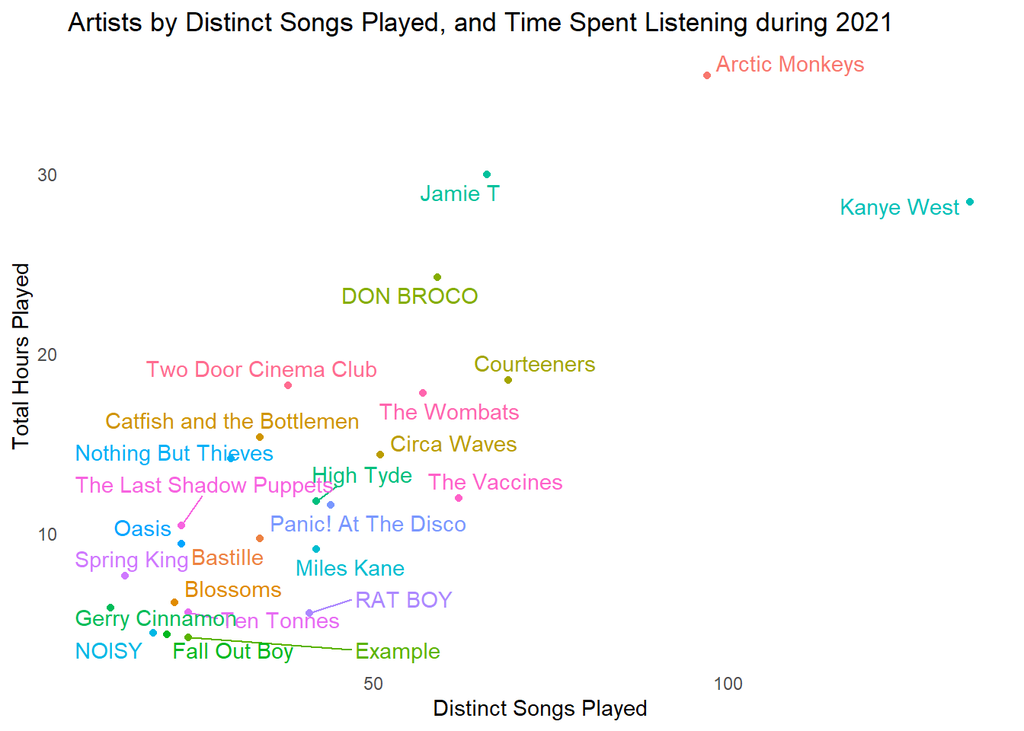

## 2022

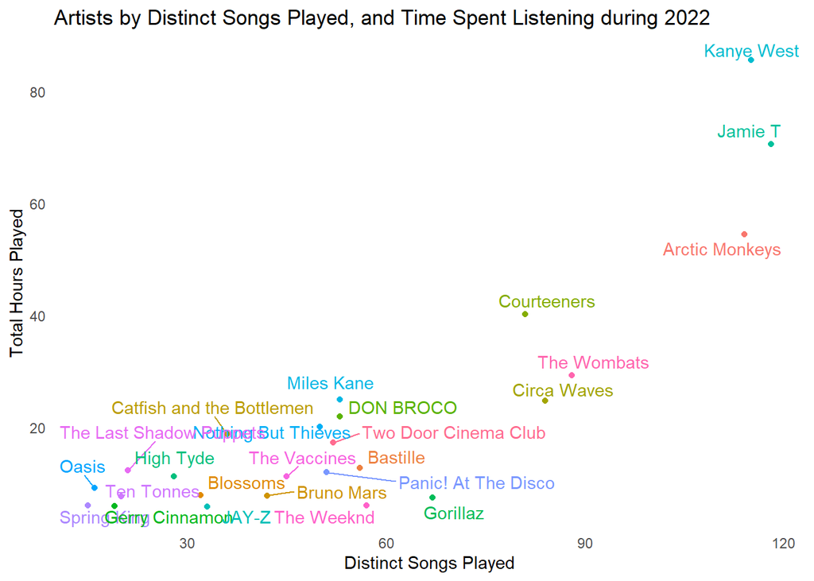

## 2023

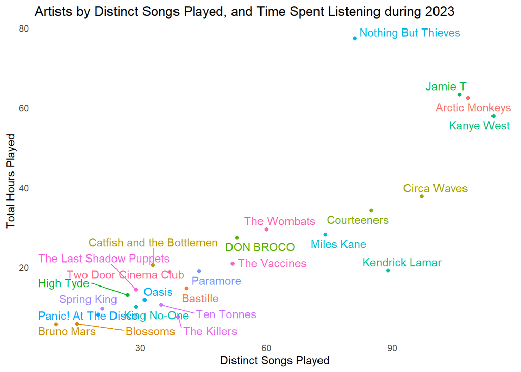

## 2024

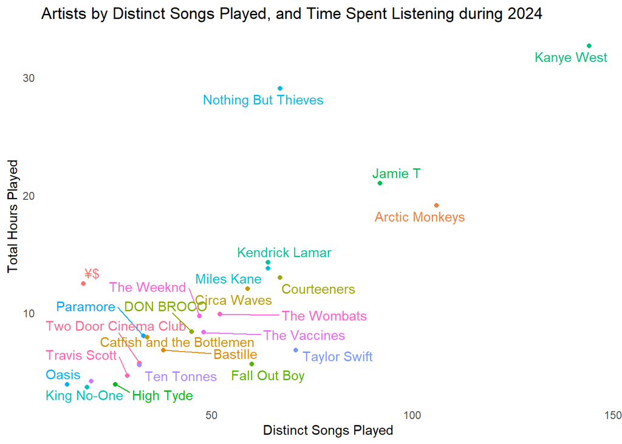